# Risk Factor Analysis

## Outcome Variable

**Outcome Variable:** stunted

## Predictor Variables

**Intervention Variable:** birthlen

**Adjustment Set:**

unadjusted

## Stratifying Variables

The analysis was stratified on these variable(s):

- agecat
- studyid
- country

## Data Summary

| agecat | studyid | country | A | n | nA | nAY0 | nAY1 |
| --- | --- | --- | --- | --- | --- | --- | --- |
| Birth | ki0047075b-MAL-ED | BANGLADESH | >=0 | 257 | 39 | 39 | 0 |
| Birth | ki0047075b-MAL-ED | BANGLADESH | <-3 | 257 | 9 | 0 | 9 |
| Birth | ki0047075b-MAL-ED | BANGLADESH | [-3–2) | 257 | 38 | 0 | 38 |
| Birth | ki0047075b-MAL-ED | BANGLADESH | [-2–1) | 257 | 83 | 83 | 0 |
| Birth | ki0047075b-MAL-ED | BANGLADESH | [-1-0) | 257 | 88 | 88 | 0 |
| Birth | ki0047075b-MAL-ED | BRAZIL | >=0 | 191 | 44 | 44 | 0 |
| Birth | ki0047075b-MAL-ED | BRAZIL | <-3 | 191 | 8 | 0 | 8 |
| Birth | ki0047075b-MAL-ED | BRAZIL | [-3–2) | 191 | 13 | 0 | 13 |
| Birth | ki0047075b-MAL-ED | BRAZIL | [-2–1) | 191 | 48 | 48 | 0 |
| Birth | ki0047075b-MAL-ED | BRAZIL | [-1-0) | 191 | 78 | 78 | 0 |
| Birth | ki0047075b-MAL-ED | INDIA | >=0 | 206 | 34 | 34 | 0 |
| Birth | ki0047075b-MAL-ED | INDIA | <-3 | 206 | 7 | 0 | 7 |
| Birth | ki0047075b-MAL-ED | INDIA | [-3–2) | 206 | 26 | 0 | 26 |
| Birth | ki0047075b-MAL-ED | INDIA | [-2–1) | 206 | 66 | 66 | 0 |
| Birth | ki0047075b-MAL-ED | INDIA | [-1-0) | 206 | 73 | 73 | 0 |
| Birth | ki0047075b-MAL-ED | NEPAL | >=0 | 173 | 45 | 45 | 0 |
| Birth | ki0047075b-MAL-ED | NEPAL | <-3 | 173 | 6 | 0 | 6 |
| Birth | ki0047075b-MAL-ED | NEPAL | [-3–2) | 173 | 12 | 0 | 12 |
| Birth | ki0047075b-MAL-ED | NEPAL | [-2–1) | 173 | 46 | 46 | 0 |
| Birth | ki0047075b-MAL-ED | NEPAL | [-1-0) | 173 | 64 | 64 | 0 |
| Birth | ki0047075b-MAL-ED | PERU | >=0 | 287 | 44 | 44 | 0 |
| Birth | ki0047075b-MAL-ED | PERU | <-3 | 287 | 8 | 0 | 8 |
| Birth | ki0047075b-MAL-ED | PERU | [-3–2) | 287 | 26 | 0 | 26 |
| Birth | ki0047075b-MAL-ED | PERU | [-2–1) | 287 | 94 | 94 | 0 |
| Birth | ki0047075b-MAL-ED | PERU | [-1-0) | 287 | 115 | 115 | 0 |
| Birth | ki0047075b-MAL-ED | SOUTH AFRICA | >=0 | 262 | 59 | 59 | 0 |
| Birth | ki0047075b-MAL-ED | SOUTH AFRICA | <-3 | 262 | 2 | 0 | 2 |
| Birth | ki0047075b-MAL-ED | SOUTH AFRICA | [-3–2) | 262 | 26 | 0 | 26 |
| Birth | ki0047075b-MAL-ED | SOUTH AFRICA | [-2–1) | 262 | 73 | 73 | 0 |
| Birth | ki0047075b-MAL-ED | SOUTH AFRICA | [-1-0) | 262 | 102 | 102 | 0 |

[output cut: 720 more lines]

The following strata were considered:

- agecat: 12 months, studyid: ki0047075b-MAL-ED, country: BANGLADESH
- agecat: 12 months, studyid: ki0047075b-MAL-ED, country: BRAZIL
- agecat: 12 months, studyid: ki0047075b-MAL-ED, country: INDIA
- agecat: 12 months, studyid: ki0047075b-MAL-ED, country: NEPAL
- agecat: 12 months, studyid: ki0047075b-MAL-ED, country: PERU
- agecat: 12 months, studyid: ki0047075b-MAL-ED, country: SOUTH AFRICA
- agecat: 12 months, studyid: ki0047075b-MAL-ED, country: TANZANIA, UNITED REPUBLIC OF
- agecat: 12 months, studyid: ki1000108-CMC-V-BCS-2002, country: INDIA
- agecat: 12 months, studyid: ki1000108-IRC, country: INDIA
- agecat: 12 months, studyid: ki1000109-EE, country: PAKISTAN
- agecat: 12 months, studyid: ki1000109-ResPak, country: PAKISTAN
- agecat: 12 months, studyid: ki1017093-NIH-Birth, country: BANGLADESH
- agecat: 12 months, studyid: ki1017093b-PROVIDE, country: BANGLADESH
- agecat: 12 months, studyid: ki1017093c-NIH-Crypto, country: BANGLADESH
- agecat: 12 months, studyid: ki1101329-Keneba, country: GAMBIA
- agecat: 12 months, studyid: ki1114097-CMIN, country: BRAZIL
- agecat: 12 months, studyid: ki1114097-CMIN, country: PERU
- agecat: 12 months, studyid: ki1114097-CONTENT, country: PERU
- agecat: 12 months, studyid: ki1126311-ZVITAMBO, country: ZIMBABWE
- agecat: 12 months, studyid: ki1135781-COHORTS, country: GUATEMALA
- agecat: 12 months, studyid: ki1135781-COHORTS, country: INDIA
- agecat: 12 months, studyid: ki1135781-COHORTS, country: PHILIPPINES
- agecat: 18 months, studyid: ki0047075b-MAL-ED, country: BANGLADESH
- agecat: 18 months, studyid: ki0047075b-MAL-ED, country: BRAZIL
- agecat: 18 months, studyid: ki0047075b-MAL-ED, country: INDIA
- agecat: 18 months, studyid: ki0047075b-MAL-ED, country: NEPAL
- agecat: 18 months, studyid: ki0047075b-MAL-ED, country: PERU
- agecat: 18 months, studyid: ki0047075b-MAL-ED, country: SOUTH AFRICA
- agecat: 18 months, studyid: ki0047075b-MAL-ED, country: TANZANIA, UNITED REPUBLIC OF
- agecat: 18 months, studyid: ki1000108-CMC-V-BCS-2002, country: INDIA
- agecat: 18 months, studyid: ki1000108-IRC, country: INDIA
- agecat: 18 months, studyid: ki1000109-EE, country: PAKISTAN
- agecat: 18 months, studyid: ki1000109-ResPak, country: PAKISTAN
- agecat: 18 months, studyid: ki1017093-NIH-Birth, country: BANGLADESH
- agecat: 18 months, studyid: ki1017093b-PROVIDE, country: BANGLADESH
- agecat: 18 months, studyid: ki1017093c-NIH-Crypto, country: BANGLADESH
- agecat: 18 months, studyid: ki1101329-Keneba, country: GAMBIA
- agecat: 18 months, studyid: ki1114097-CMIN, country: BRAZIL
- agecat: 18 months, studyid: ki1114097-CMIN, country: PERU
- agecat: 18 months, studyid: ki1114097-CONTENT, country: PERU
- agecat: 18 months, studyid: ki1126311-ZVITAMBO, country: ZIMBABWE
- agecat: 18 months, studyid: ki1135781-COHORTS, country: GUATEMALA
- agecat: 18 months, studyid: ki1135781-COHORTS, country: PHILIPPINES
- agecat: 24 months, studyid: ki0047075b-MAL-ED, country: BANGLADESH
- agecat: 24 months, studyid: ki0047075b-MAL-ED, country: BRAZIL
- agecat: 24 months, studyid: ki0047075b-MAL-ED, country: INDIA
- agecat: 24 months, studyid: ki0047075b-MAL-ED, country: NEPAL
- agecat: 24 months, studyid: ki0047075b-MAL-ED, country: PERU
- agecat: 24 months, studyid: ki0047075b-MAL-ED, country: SOUTH AFRICA
- agecat: 24 months, studyid: ki0047075b-MAL-ED, country: TANZANIA, UNITED REPUBLIC OF
- agecat: 24 months, studyid: ki1000108-CMC-V-BCS-2002, country: INDIA
- agecat: 24 months, studyid: ki1000108-IRC, country: INDIA
- agecat: 24 months, studyid: ki1017093-NIH-Birth, country: BANGLADESH
- agecat: 24 months, studyid: ki1017093b-PROVIDE, country: BANGLADESH
- agecat: 24 months, studyid: ki1017093c-NIH-Crypto, country: BANGLADESH
- agecat: 24 months, studyid: ki1101329-Keneba, country: GAMBIA
- agecat: 24 months, studyid: ki1114097-CMIN, country: PERU
- agecat: 24 months, studyid: ki1114097-CONTENT, country: PERU
- agecat: 24 months, studyid: ki1126311-ZVITAMBO, country: ZIMBABWE
- agecat: 24 months, studyid: ki1135781-COHORTS, country: GUATEMALA
- agecat: 24 months, studyid: ki1135781-COHORTS, country: INDIA
- agecat: 24 months, studyid: ki1135781-COHORTS, country: PHILIPPINES
- agecat: 3 months, studyid: ki0047075b-MAL-ED, country: BANGLADESH
- agecat: 3 months, studyid: ki0047075b-MAL-ED, country: BRAZIL
- agecat: 3 months, studyid: ki0047075b-MAL-ED, country: INDIA
- agecat: 3 months, studyid: ki0047075b-MAL-ED, country: NEPAL
- agecat: 3 months, studyid: ki0047075b-MAL-ED, country: PERU
- agecat: 3 months, studyid: ki0047075b-MAL-ED, country: SOUTH AFRICA
- agecat: 3 months, studyid: ki0047075b-MAL-ED, country: TANZANIA, UNITED REPUBLIC OF
- agecat: 3 months, studyid: ki1000108-CMC-V-BCS-2002, country: INDIA
- agecat: 3 months, studyid: ki1000108-IRC, country: INDIA
- agecat: 3 months, studyid: ki1000109-EE, country: PAKISTAN
- agecat: 3 months, studyid: ki1000109-ResPak, country: PAKISTAN
- agecat: 3 months, studyid: ki1017093-NIH-Birth, country: BANGLADESH
- agecat: 3 months, studyid: ki1017093b-PROVIDE, country: BANGLADESH
- agecat: 3 months, studyid: ki1017093c-NIH-Crypto, country: BANGLADESH
- agecat: 3 months, studyid: ki1101329-Keneba, country: GAMBIA
- agecat: 3 months, studyid: ki1114097-CMIN, country: BRAZIL
- agecat: 3 months, studyid: ki1114097-CMIN, country: PERU
- agecat: 3 months, studyid: ki1114097-CONTENT, country: PERU
- agecat: 3 months, studyid: ki1126311-ZVITAMBO, country: ZIMBABWE
- agecat: 3 months, studyid: ki1135781-COHORTS, country: GUATEMALA
- agecat: 3 months, studyid: ki1135781-COHORTS, country: INDIA
- agecat: 3 months, studyid: ki1135781-COHORTS, country: PHILIPPINES
- agecat: 6 months, studyid: ki0047075b-MAL-ED, country: BANGLADESH
- agecat: 6 months, studyid: ki0047075b-MAL-ED, country: BRAZIL
- agecat: 6 months, studyid: ki0047075b-MAL-ED, country: INDIA
- agecat: 6 months, studyid: ki0047075b-MAL-ED, country: NEPAL
- agecat: 6 months, studyid: ki0047075b-MAL-ED, country: PERU
- agecat: 6 months, studyid: ki0047075b-MAL-ED, country: SOUTH AFRICA
- agecat: 6 months, studyid: ki0047075b-MAL-ED, country: TANZANIA, UNITED REPUBLIC OF
- agecat: 6 months, studyid: ki1000108-CMC-V-BCS-2002, country: INDIA
- agecat: 6 months, studyid: ki1000108-IRC, country: INDIA
- agecat: 6 months, studyid: ki1000109-EE, country: PAKISTAN
- agecat: 6 months, studyid: ki1000109-ResPak, country: PAKISTAN
- agecat: 6 months, studyid: ki1017093-NIH-Birth, country: BANGLADESH
- agecat: 6 months, studyid: ki1017093b-PROVIDE, country: BANGLADESH
- agecat: 6 months, studyid: ki1017093c-NIH-Crypto, country: BANGLADESH
- agecat: 6 months, studyid: ki1101329-Keneba, country: GAMBIA
- agecat: 6 months, studyid: ki1114097-CMIN, country: BRAZIL
- agecat: 6 months, studyid: ki1114097-CMIN, country: PERU
- agecat: 6 months, studyid: ki1114097-CONTENT, country: PERU
- agecat: 6 months, studyid: ki1126311-ZVITAMBO, country: ZIMBABWE
- agecat: 6 months, studyid: ki1135781-COHORTS, country: GUATEMALA
- agecat: 6 months, studyid: ki1135781-COHORTS, country: INDIA
- agecat: 6 months, studyid: ki1135781-COHORTS, country: PHILIPPINES
- agecat: 9 months, studyid: ki0047075b-MAL-ED, country: BANGLADESH
- agecat: 9 months, studyid: ki0047075b-MAL-ED, country: BRAZIL
- agecat: 9 months, studyid: ki0047075b-MAL-ED, country: INDIA
- agecat: 9 months, studyid: ki0047075b-MAL-ED, country: NEPAL
- agecat: 9 months, studyid: ki0047075b-MAL-ED, country: PERU
- agecat: 9 months, studyid: ki0047075b-MAL-ED, country: SOUTH AFRICA
- agecat: 9 months, studyid: ki0047075b-MAL-ED, country: TANZANIA, UNITED REPUBLIC OF
- agecat: 9 months, studyid: ki1000108-CMC-V-BCS-2002, country: INDIA
- agecat: 9 months, studyid: ki1000108-IRC, country: INDIA
- agecat: 9 months, studyid: ki1000109-EE, country: PAKISTAN
- agecat: 9 months, studyid: ki1000109-ResPak, country: PAKISTAN
- agecat: 9 months, studyid: ki1017093-NIH-Birth, country: BANGLADESH
- agecat: 9 months, studyid: ki1017093b-PROVIDE, country: BANGLADESH
- agecat: 9 months, studyid: ki1017093c-NIH-Crypto, country: BANGLADESH
- agecat: 9 months, studyid: ki1101329-Keneba, country: GAMBIA
- agecat: 9 months, studyid: ki1114097-CMIN, country: BRAZIL
- agecat: 9 months, studyid: ki1114097-CMIN, country: PERU
- agecat: 9 months, studyid: ki1114097-CONTENT, country: PERU
- agecat: 9 months, studyid: ki1126311-ZVITAMBO, country: ZIMBABWE
- agecat: 9 months, studyid: ki1135781-COHORTS, country: GUATEMALA
- agecat: 9 months, studyid: ki1135781-COHORTS, country: INDIA
- agecat: 9 months, studyid: ki1135781-COHORTS, country: PHILIPPINES
- agecat: Birth, studyid: ki0047075b-MAL-ED, country: BANGLADESH
- agecat: Birth, studyid: ki0047075b-MAL-ED, country: BRAZIL
- agecat: Birth, studyid: ki0047075b-MAL-ED, country: INDIA
- agecat: Birth, studyid: ki0047075b-MAL-ED, country: NEPAL
- agecat: Birth, studyid: ki0047075b-MAL-ED, country: PERU
- agecat: Birth, studyid: ki0047075b-MAL-ED, country: SOUTH AFRICA
- agecat: Birth, studyid: ki0047075b-MAL-ED, country: TANZANIA, UNITED REPUBLIC OF
- agecat: Birth, studyid: ki1000108-CMC-V-BCS-2002, country: INDIA
- agecat: Birth, studyid: ki1000108-IRC, country: INDIA
- agecat: Birth, studyid: ki1000109-EE, country: PAKISTAN
- agecat: Birth, studyid: ki1000109-ResPak, country: PAKISTAN
- agecat: Birth, studyid: ki1017093-NIH-Birth, country: BANGLADESH
- agecat: Birth, studyid: ki1017093c-NIH-Crypto, country: BANGLADESH
- agecat: Birth, studyid: ki1101329-Keneba, country: GAMBIA
- agecat: Birth, studyid: ki1114097-CMIN, country: BANGLADESH
- agecat: Birth, studyid: ki1114097-CMIN, country: BRAZIL
- agecat: Birth, studyid: ki1114097-CMIN, country: PERU
- agecat: Birth, studyid: ki1114097-CONTENT, country: PERU
- agecat: Birth, studyid: ki1126311-ZVITAMBO, country: ZIMBABWE
- agecat: Birth, studyid: ki1135781-COHORTS, country: GUATEMALA
- agecat: Birth, studyid: ki1135781-COHORTS, country: INDIA
- agecat: Birth, studyid: ki1135781-COHORTS, country: PHILIPPINES

### Dropped Strata

Some strata were dropped due to rare outcomes:

- agecat: Birth, studyid: ki0047075b-MAL-ED, country: BANGLADESH
- agecat: Birth, studyid: ki0047075b-MAL-ED, country: BRAZIL
- agecat: Birth, studyid: ki0047075b-MAL-ED, country: INDIA
- agecat: Birth, studyid: ki0047075b-MAL-ED, country: NEPAL
- agecat: Birth, studyid: ki0047075b-MAL-ED, country: PERU
- agecat: Birth, studyid: ki0047075b-MAL-ED, country: SOUTH AFRICA
- agecat: Birth, studyid: ki0047075b-MAL-ED, country: TANZANIA, UNITED REPUBLIC OF
- agecat: Birth, studyid: ki1000108-CMC-V-BCS-2002, country: INDIA
- agecat: Birth, studyid: ki1000108-IRC, country: INDIA
- agecat: Birth, studyid: ki1000109-EE, country: PAKISTAN
- agecat: Birth, studyid: ki1000109-ResPak, country: PAKISTAN
- agecat: Birth, studyid: ki1017093-NIH-Birth, country: BANGLADESH
- agecat: Birth, studyid: ki1017093c-NIH-Crypto, country: BANGLADESH
- agecat: Birth, studyid: ki1101329-Keneba, country: GAMBIA
- agecat: Birth, studyid: ki1114097-CMIN, country: BANGLADESH
- agecat: Birth, studyid: ki1114097-CMIN, country: BRAZIL
- agecat: Birth, studyid: ki1114097-CMIN, country: PERU
- agecat: Birth, studyid: ki1114097-CONTENT, country: PERU
- agecat: Birth, studyid: ki1126311-ZVITAMBO, country: ZIMBABWE
- agecat: Birth, studyid: ki1135781-COHORTS, country: GUATEMALA
- agecat: Birth, studyid: ki1135781-COHORTS, country: INDIA
- agecat: Birth, studyid: ki1135781-COHORTS, country: PHILIPPINES
- agecat: 3 months, studyid: ki0047075b-MAL-ED, country: BANGLADESH
- agecat: 3 months, studyid: ki0047075b-MAL-ED, country: BRAZIL
- agecat: 3 months, studyid: ki0047075b-MAL-ED, country: INDIA
- agecat: 3 months, studyid: ki0047075b-MAL-ED, country: NEPAL
- agecat: 3 months, studyid: ki0047075b-MAL-ED, country: PERU
- agecat: 3 months, studyid: ki0047075b-MAL-ED, country: SOUTH AFRICA
- agecat: 3 months, studyid: ki0047075b-MAL-ED, country: TANZANIA, UNITED REPUBLIC OF
- agecat: 3 months, studyid: ki1000108-CMC-V-BCS-2002, country: INDIA
- agecat: 3 months, studyid: ki1000109-EE, country: PAKISTAN
- agecat: 3 months, studyid: ki1000109-ResPak, country: PAKISTAN
- agecat: 3 months, studyid: ki1017093-NIH-Birth, country: BANGLADESH
- agecat: 3 months, studyid: ki1017093b-PROVIDE, country: BANGLADESH
- agecat: 3 months, studyid: ki1017093c-NIH-Crypto, country: BANGLADESH
- agecat: 3 months, studyid: ki1114097-CMIN, country: BRAZIL
- agecat: 3 months, studyid: ki1114097-CMIN, country: PERU
- agecat: 3 months, studyid: ki1114097-CONTENT, country: PERU
- agecat: 3 months, studyid: ki1135781-COHORTS, country: GUATEMALA
- agecat: 6 months, studyid: ki0047075b-MAL-ED, country: BANGLADESH
- agecat: 6 months, studyid: ki0047075b-MAL-ED, country: BRAZIL
- agecat: 6 months, studyid: ki0047075b-MAL-ED, country: INDIA
- agecat: 6 months, studyid: ki0047075b-MAL-ED, country: NEPAL
- agecat: 6 months, studyid: ki0047075b-MAL-ED, country: PERU
- agecat: 6 months, studyid: ki0047075b-MAL-ED, country: SOUTH AFRICA
- agecat: 6 months, studyid: ki0047075b-MAL-ED, country: TANZANIA, UNITED REPUBLIC OF
- agecat: 6 months, studyid: ki1000108-CMC-V-BCS-2002, country: INDIA
- agecat: 6 months, studyid: ki1000109-EE, country: PAKISTAN
- agecat: 6 months, studyid: ki1000109-ResPak, country: PAKISTAN
- agecat: 6 months, studyid: ki1017093-NIH-Birth, country: BANGLADESH
- agecat: 6 months, studyid: ki1017093b-PROVIDE, country: BANGLADESH
- agecat: 6 months, studyid: ki1017093c-NIH-Crypto, country: BANGLADESH
- agecat: 6 months, studyid: ki1114097-CMIN, country: BRAZIL
- agecat: 6 months, studyid: ki1114097-CMIN, country: PERU
- agecat: 6 months, studyid: ki1114097-CONTENT, country: PERU
- agecat: 6 months, studyid: ki1135781-COHORTS, country: GUATEMALA
- agecat: 6 months, studyid: ki1135781-COHORTS, country: PHILIPPINES
- agecat: 9 months, studyid: ki0047075b-MAL-ED, country: BANGLADESH
- agecat: 9 months, studyid: ki0047075b-MAL-ED, country: BRAZIL
- agecat: 9 months, studyid: ki0047075b-MAL-ED, country: INDIA
- agecat: 9 months, studyid: ki0047075b-MAL-ED, country: NEPAL
- agecat: 9 months, studyid: ki0047075b-MAL-ED, country: PERU
- agecat: 9 months, studyid: ki0047075b-MAL-ED, country: SOUTH AFRICA
- agecat: 9 months, studyid: ki0047075b-MAL-ED, country: TANZANIA, UNITED REPUBLIC OF
- agecat: 9 months, studyid: ki1000108-CMC-V-BCS-2002, country: INDIA
- agecat: 9 months, studyid: ki1000109-EE, country: PAKISTAN
- agecat: 9 months, studyid: ki1000109-ResPak, country: PAKISTAN
- agecat: 9 months, studyid: ki1017093-NIH-Birth, country: BANGLADESH
- agecat: 9 months, studyid: ki1017093b-PROVIDE, country: BANGLADESH
- agecat: 9 months, studyid: ki1017093c-NIH-Crypto, country: BANGLADESH
- agecat: 9 months, studyid: ki1114097-CMIN, country: BRAZIL
- agecat: 9 months, studyid: ki1114097-CMIN, country: PERU
- agecat: 9 months, studyid: ki1114097-CONTENT, country: PERU
- agecat: 9 months, studyid: ki1135781-COHORTS, country: GUATEMALA
- agecat: 12 months, studyid: ki0047075b-MAL-ED, country: BANGLADESH
- agecat: 12 months, studyid: ki0047075b-MAL-ED, country: BRAZIL
- agecat: 12 months, studyid: ki0047075b-MAL-ED, country: INDIA
- agecat: 12 months, studyid: ki0047075b-MAL-ED, country: NEPAL
- agecat: 12 months, studyid: ki0047075b-MAL-ED, country: PERU
- agecat: 12 months, studyid: ki0047075b-MAL-ED, country: SOUTH AFRICA
- agecat: 12 months, studyid: ki0047075b-MAL-ED, country: TANZANIA, UNITED REPUBLIC OF
- agecat: 12 months, studyid: ki1000108-CMC-V-BCS-2002, country: INDIA
- agecat: 12 months, studyid: ki1000109-EE, country: PAKISTAN
- agecat: 12 months, studyid: ki1000109-ResPak, country: PAKISTAN
- agecat: 12 months, studyid: ki1017093-NIH-Birth, country: BANGLADESH
- agecat: 12 months, studyid: ki1017093b-PROVIDE, country: BANGLADESH
- agecat: 12 months, studyid: ki1017093c-NIH-Crypto, country: BANGLADESH
- agecat: 12 months, studyid: ki1114097-CMIN, country: BRAZIL
- agecat: 12 months, studyid: ki1114097-CMIN, country: PERU
- agecat: 12 months, studyid: ki1114097-CONTENT, country: PERU
- agecat: 12 months, studyid: ki1135781-COHORTS, country: GUATEMALA
- agecat: 12 months, studyid: ki1135781-COHORTS, country: PHILIPPINES
- agecat: 18 months, studyid: ki0047075b-MAL-ED, country: BANGLADESH
- agecat: 18 months, studyid: ki0047075b-MAL-ED, country: BRAZIL
- agecat: 18 months, studyid: ki0047075b-MAL-ED, country: INDIA
- agecat: 18 months, studyid: ki0047075b-MAL-ED, country: NEPAL
- agecat: 18 months, studyid: ki0047075b-MAL-ED, country: PERU
- agecat: 18 months, studyid: ki0047075b-MAL-ED, country: SOUTH AFRICA
- agecat: 18 months, studyid: ki0047075b-MAL-ED, country: TANZANIA, UNITED REPUBLIC OF
- agecat: 18 months, studyid: ki1000108-CMC-V-BCS-2002, country: INDIA
- agecat: 18 months, studyid: ki1000109-EE, country: PAKISTAN
- agecat: 18 months, studyid: ki1000109-ResPak, country: PAKISTAN
- agecat: 18 months, studyid: ki1017093-NIH-Birth, country: BANGLADESH
- agecat: 18 months, studyid: ki1017093b-PROVIDE, country: BANGLADESH
- agecat: 18 months, studyid: ki1017093c-NIH-Crypto, country: BANGLADESH
- agecat: 18 months, studyid: ki1114097-CMIN, country: BRAZIL
- agecat: 18 months, studyid: ki1114097-CMIN, country: PERU
- agecat: 18 months, studyid: ki1114097-CONTENT, country: PERU
- agecat: 18 months, studyid: ki1135781-COHORTS, country: GUATEMALA
- agecat: 18 months, studyid: ki1135781-COHORTS, country: PHILIPPINES
- agecat: 24 months, studyid: ki0047075b-MAL-ED, country: BANGLADESH
- agecat: 24 months, studyid: ki0047075b-MAL-ED, country: BRAZIL
- agecat: 24 months, studyid: ki0047075b-MAL-ED, country: INDIA
- agecat: 24 months, studyid: ki0047075b-MAL-ED, country: NEPAL
- agecat: 24 months, studyid: ki0047075b-MAL-ED, country: PERU
- agecat: 24 months, studyid: ki0047075b-MAL-ED, country: SOUTH AFRICA
- agecat: 24 months, studyid: ki0047075b-MAL-ED, country: TANZANIA, UNITED REPUBLIC OF
- agecat: 24 months, studyid: ki1000108-CMC-V-BCS-2002, country: INDIA
- agecat: 24 months, studyid: ki1017093-NIH-Birth, country: BANGLADESH
- agecat: 24 months, studyid: ki1017093b-PROVIDE, country: BANGLADESH
- agecat: 24 months, studyid: ki1017093c-NIH-Crypto, country: BANGLADESH
- agecat: 24 months, studyid: ki1114097-CMIN, country: PERU
- agecat: 24 months, studyid: ki1114097-CONTENT, country: PERU
- agecat: 24 months, studyid: ki1126311-ZVITAMBO, country: ZIMBABWE
- agecat: 24 months, studyid: ki1135781-COHORTS, country: GUATEMALA
- agecat: 24 months, studyid: ki1135781-COHORTS, country: PHILIPPINES

## Methods Detail

We’re interested in the causal parameters $E[Y_a]$ for all values of $a \in \mathcal{A}$. These parameters represent the mean outcome if, possibly contrary to fact, we intervened to set all units to have $A=a$. Under the randomization and positivity assumptions, these are identified by the statistical parameters $\psi_a=E_W[E_{Y|A,W}(Y|A=a,W)]$. In addition, we’re interested in the mean of $Y$, $E[Y]$ under no intervention (the observed mean). We will estimate these parameters by using SuperLearner to fit the relevant likelihood factors – $E_{Y|A,W}(Y|A=a,W)$ and $p(A=a|W)$, and then updating our likelihood fit using a joint TMLE.

For unadjusted analyses ($W=\{\}$), initial likelihoods were estimated using Lrnr_glm to estimate the simple $E(Y|A)$ and Lrnr_mean to estimate $p(A)$. For adjusted analyses, a small library containing Lrnr_glmnet, Lrnr_xgboost, and Lrnr_mean was used.

Having estimated these parameters, we will then use the delta method to estimate relative risks and attributable risks relative to a prespecified baseline level of $A$.

# Results Detail

## Results Plots

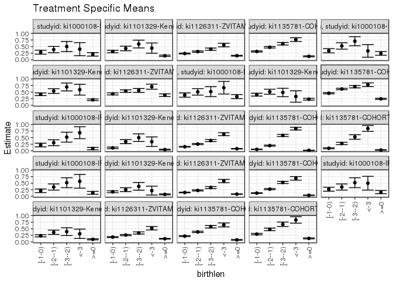

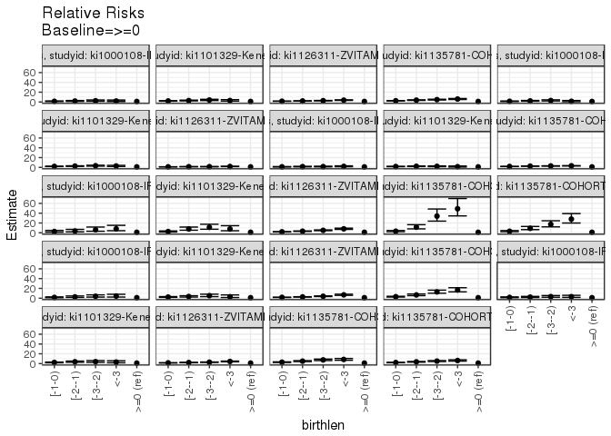

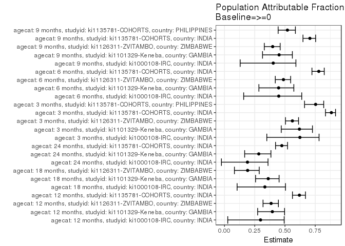

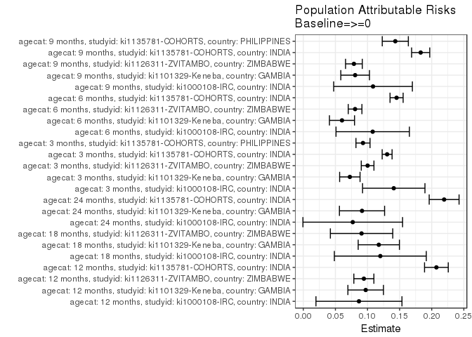

## Results Table

### Parameter: TSM

| agecat | studyid | country | intervention_level | baseline_level | estimate | ci_lower | ci_upper |
| --- | --- | --- | --- | --- | --- | --- | --- |
| 3 months | ki1000108-IRC | INDIA | >=0 | NA | 0.0851064 | 0.0389885 | 0.1312243 |
| 3 months | ki1000108-IRC | INDIA | <-3 | NA | 0.6875000 | 0.4600876 | 0.9149124 |
| 3 months | ki1000108-IRC | INDIA | [-3–2) | NA | 0.5185185 | 0.3298051 | 0.7072320 |
| 3 months | ki1000108-IRC | INDIA | [-2–1) | NA | 0.3076923 | 0.1953446 | 0.4200400 |
| 3 months | ki1000108-IRC | INDIA | [-1-0) | NA | 0.2205882 | 0.1508103 | 0.2903662 |
| 3 months | ki1101329-Keneba | GAMBIA | >=0 | NA | 0.0445026 | 0.0298754 | 0.0591298 |
| 3 months | ki1101329-Keneba | GAMBIA | <-3 | NA | 0.3461538 | 0.1632230 | 0.5290847 |
| 3 months | ki1101329-Keneba | GAMBIA | [-3–2) | NA | 0.5000000 | 0.3554586 | 0.6445414 |
| 3 months | ki1101329-Keneba | GAMBIA | [-2–1) | NA | 0.3489933 | 0.2724320 | 0.4255546 |
| 3 months | ki1101329-Keneba | GAMBIA | [-1-0) | NA | 0.1105991 | 0.0810815 | 0.1401167 |
| 3 months | ki1126311-ZVITAMBO | ZIMBABWE | >=0 | NA | 0.0782178 | 0.0686565 | 0.0877791 |
| 3 months | ki1126311-ZVITAMBO | ZIMBABWE | <-3 | NA | 0.6321429 | 0.5756569 | 0.6886288 |
| 3 months | ki1126311-ZVITAMBO | ZIMBABWE | [-3–2) | NA | 0.3890675 | 0.3507510 | 0.4273840 |
| 3 months | ki1126311-ZVITAMBO | ZIMBABWE | [-2–1) | NA | 0.2550415 | 0.2342343 | 0.2758488 |
| 3 months | ki1126311-ZVITAMBO | ZIMBABWE | [-1-0) | NA | 0.1538910 | 0.1418162 | 0.1659658 |
| 3 months | ki1135781-COHORTS | INDIA | >=0 | NA | 0.0171745 | 0.0111804 | 0.0231686 |
| 3 months | ki1135781-COHORTS | INDIA | <-3 | NA | 0.8426396 | 0.7917865 | 0.8934927 |
| 3 months | ki1135781-COHORTS | INDIA | [-3–2) | NA | 0.5839286 | 0.5431012 | 0.6247559 |
| 3 months | ki1135781-COHORTS | INDIA | [-2–1) | NA | 0.1968607 | 0.1769286 | 0.2167928 |
| 3 months | ki1135781-COHORTS | INDIA | [-1-0) | NA | 0.0547599 | 0.0456073 | 0.0639125 |
| 3 months | ki1135781-COHORTS | PHILIPPINES | >=0 | NA | 0.0304243 | 0.0208976 | 0.0399511 |
| 3 months | ki1135781-COHORTS | PHILIPPINES | <-3 | NA | 0.8500000 | 0.7393252 | 0.9606748 |
| 3 months | ki1135781-COHORTS | PHILIPPINES | [-3–2) | NA | 0.5238095 | 0.4365896 | 0.6110294 |
| 3 months | ki1135781-COHORTS | PHILIPPINES | [-2–1) | NA | 0.2776471 | 0.2350627 | 0.3202315 |
| 3 months | ki1135781-COHORTS | PHILIPPINES | [-1-0) | NA | 0.0952381 | 0.0772995 | 0.1131767 |
| 6 months | ki1000108-IRC | INDIA | >=0 | NA | 0.1328671 | 0.0771620 | 0.1885722 |
| 6 months | ki1000108-IRC | INDIA | <-3 | NA | 0.5714286 | 0.3118673 | 0.8309899 |
| 6 months | ki1000108-IRC | INDIA | [-3–2) | NA | 0.5185185 | 0.3298057 | 0.7072313 |
| 6 months | ki1000108-IRC | INDIA | [-2–1) | NA | 0.3538462 | 0.2374523 | 0.4702400 |
| 6 months | ki1000108-IRC | INDIA | [-1-0) | NA | 0.2116788 | 0.1431866 | 0.2801711 |

[output cut: 90 more lines]

### Parameter: E(Y)

| agecat | studyid | country | intervention_level | baseline_level | estimate | ci_lower | ci_upper |
| --- | --- | --- | --- | --- | --- | --- | --- |
| 3 months | ki1000108-IRC | INDIA | NA | NA | 0.2259740 | 0.2107202 | 0.2412279 |
| 3 months | ki1101329-Keneba | GAMBIA | NA | NA | 0.1169838 | 0.1107790 | 0.1231885 |
| 3 months | ki1126311-ZVITAMBO | ZIMBABWE | NA | NA | 0.1783622 | 0.1759152 | 0.1808093 |
| 3 months | ki1135781-COHORTS | INDIA | NA | NA | 0.1477185 | 0.1428612 | 0.1525757 |
| 3 months | ki1135781-COHORTS | PHILIPPINES | NA | NA | 0.1233879 | 0.1179628 | 0.1288131 |
| 6 months | ki1000108-IRC | INDIA | NA | NA | 0.2409326 | 0.2282470 | 0.2536183 |
| 6 months | ki1101329-Keneba | GAMBIA | NA | NA | 0.1346298 | 0.1305331 | 0.1387265 |
| 6 months | ki1126311-ZVITAMBO | ZIMBABWE | NA | NA | 0.1655037 | 0.1633297 | 0.1676778 |
| 6 months | ki1135781-COHORTS | INDIA | NA | NA | 0.1863384 | 0.1822776 | 0.1903992 |
| 9 months | ki1000108-IRC | INDIA | NA | NA | 0.2694301 | 0.2585624 | 0.2802977 |
| 9 months | ki1101329-Keneba | GAMBIA | NA | NA | 0.1787879 | 0.1734695 | 0.1841063 |
| 9 months | ki1126311-ZVITAMBO | ZIMBABWE | NA | NA | 0.1979608 | 0.1960272 | 0.1998944 |
| 9 months | ki1135781-COHORTS | INDIA | NA | NA | 0.2589506 | 0.2545752 | 0.2633259 |
| 9 months | ki1135781-COHORTS | PHILIPPINES | NA | NA | 0.2754159 | 0.2693172 | 0.2815146 |
| 12 months | ki1000108-IRC | INDIA | NA | NA | 0.2909091 | 0.2821417 | 0.2996765 |
| 12 months | ki1101329-Keneba | GAMBIA | NA | NA | 0.2455139 | 0.2387174 | 0.2523104 |
| 12 months | ki1126311-ZVITAMBO | ZIMBABWE | NA | NA | 0.2446857 | 0.2424970 | 0.2468744 |
| 12 months | ki1135781-COHORTS | INDIA | NA | NA | 0.3346105 | 0.3297952 | 0.3394257 |
| 18 months | ki1000108-IRC | INDIA | NA | NA | 0.3593750 | 0.3458120 | 0.3729380 |
| 18 months | ki1101329-Keneba | GAMBIA | NA | NA | 0.3252101 | 0.3171636 | 0.3332566 |
| 18 months | ki1126311-ZVITAMBO | ZIMBABWE | NA | NA | 0.4747475 | 0.4707252 | 0.4787697 |
| 24 months | ki1000108-IRC | INDIA | NA | NA | 0.4056848 | 0.3969920 | 0.4143775 |
| 24 months | ki1101329-Keneba | GAMBIA | NA | NA | 0.3226112 | 0.3162675 | 0.3289548 |
| 24 months | ki1135781-COHORTS | INDIA | NA | NA | 0.4627179 | 0.4580312 | 0.4674046 |

### Parameter: RR

| agecat | studyid | country | intervention_level | baseline_level | estimate | ci_lower | ci_upper |
| --- | --- | --- | --- | --- | --- | --- | --- |
| 3 months | ki1000108-IRC | INDIA | >=0 | >=0 | 1.000000 | 1.0000000 | 1.000000 |
| 3 months | ki1000108-IRC | INDIA | <-3 | >=0 | 8.078125 | 4.2814534 | 15.241577 |
| 3 months | ki1000108-IRC | INDIA | [-3–2) | >=0 | 6.092593 | 3.1718411 | 11.702883 |
| 3 months | ki1000108-IRC | INDIA | [-2–1) | >=0 | 3.615385 | 1.8809495 | 6.949153 |
| 3 months | ki1000108-IRC | INDIA | [-1-0) | >=0 | 2.591912 | 1.3839457 | 4.854241 |
| 3 months | ki1101329-Keneba | GAMBIA | >=0 | >=0 | 1.000000 | 1.0000000 | 1.000000 |
| 3 months | ki1101329-Keneba | GAMBIA | <-3 | >=0 | 7.778280 | 4.1744955 | 14.493163 |
| 3 months | ki1101329-Keneba | GAMBIA | [-3–2) | >=0 | 11.235294 | 7.2524370 | 17.405436 |
| 3 months | ki1101329-Keneba | GAMBIA | [-2–1) | >=0 | 7.842084 | 5.2821622 | 11.642635 |
| 3 months | ki1101329-Keneba | GAMBIA | [-1-0) | >=0 | 2.485226 | 1.6273793 | 3.795273 |
| 3 months | ki1126311-ZVITAMBO | ZIMBABWE | >=0 | >=0 | 1.000000 | 1.0000000 | 1.000000 |
| 3 months | ki1126311-ZVITAMBO | ZIMBABWE | <-3 | >=0 | 8.081826 | 6.9462434 | 9.403056 |
| 3 months | ki1126311-ZVITAMBO | ZIMBABWE | [-3–2) | >=0 | 4.974154 | 4.2515326 | 5.819598 |
| 3 months | ki1126311-ZVITAMBO | ZIMBABWE | [-2–1) | >=0 | 3.260657 | 2.8150070 | 3.776860 |
| 3 months | ki1126311-ZVITAMBO | ZIMBABWE | [-1-0) | >=0 | 1.967467 | 1.7014687 | 2.275050 |
| 3 months | ki1135781-COHORTS | INDIA | >=0 | >=0 | 1.000000 | 1.0000000 | 1.000000 |
| 3 months | ki1135781-COHORTS | INDIA | <-3 | >=0 | 49.063367 | 34.4297992 | 69.916585 |
| 3 months | ki1135781-COHORTS | INDIA | [-3–2) | >=0 | 33.999710 | 23.8171636 | 48.535598 |
| 3 months | ki1135781-COHORTS | INDIA | [-2–1) | >=0 | 11.462372 | 7.9698756 | 16.485323 |
| 3 months | ki1135781-COHORTS | INDIA | [-1-0) | >=0 | 3.188439 | 2.1653092 | 4.695008 |
| 3 months | ki1135781-COHORTS | PHILIPPINES | >=0 | >=0 | 1.000000 | 1.0000000 | 1.000000 |
| 3 months | ki1135781-COHORTS | PHILIPPINES | <-3 | >=0 | 27.938158 | 19.9030376 | 39.217163 |
| 3 months | ki1135781-COHORTS | PHILIPPINES | [-3–2) | >=0 | 17.216792 | 12.0762043 | 24.545620 |
| 3 months | ki1135781-COHORTS | PHILIPPINES | [-2–1) | >=0 | 9.125820 | 6.4393879 | 12.932999 |
| 3 months | ki1135781-COHORTS | PHILIPPINES | [-1-0) | >=0 | 3.130326 | 2.1721625 | 4.511145 |
| 6 months | ki1000108-IRC | INDIA | >=0 | >=0 | 1.000000 | 1.0000000 | 1.000000 |
| 6 months | ki1000108-IRC | INDIA | <-3 | >=0 | 4.300752 | 2.3178653 | 7.979957 |
| 6 months | ki1000108-IRC | INDIA | [-3–2) | >=0 | 3.902534 | 2.2399212 | 6.799245 |
| 6 months | ki1000108-IRC | INDIA | [-2–1) | >=0 | 2.663158 | 1.5630196 | 4.537634 |
| 6 months | ki1000108-IRC | INDIA | [-1-0) | >=0 | 1.593162 | 0.9381239 | 2.705575 |

[output cut: 90 more lines]

### Parameter: PAR

| agecat | studyid | country | intervention_level | baseline_level | estimate | ci_lower | ci_upper |
| --- | --- | --- | --- | --- | --- | --- | --- |
| 3 months | ki1000108-IRC | INDIA | >=0 | NA | 0.1408676 | 0.0922925 | 0.1894428 |
| 3 months | ki1101329-Keneba | GAMBIA | >=0 | NA | 0.0724812 | 0.0565924 | 0.0883700 |
| 3 months | ki1126311-ZVITAMBO | ZIMBABWE | >=0 | NA | 0.1001444 | 0.0902749 | 0.1100139 |
| 3 months | ki1135781-COHORTS | INDIA | >=0 | NA | 0.1305440 | 0.1228289 | 0.1382590 |
| 3 months | ki1135781-COHORTS | PHILIPPINES | >=0 | NA | 0.0929636 | 0.0820004 | 0.1039268 |
| 6 months | ki1000108-IRC | INDIA | >=0 | NA | 0.1080655 | 0.0509342 | 0.1651968 |
| 6 months | ki1101329-Keneba | GAMBIA | >=0 | NA | 0.0602496 | 0.0407215 | 0.0797777 |
| 6 months | ki1126311-ZVITAMBO | ZIMBABWE | >=0 | NA | 0.0806530 | 0.0700056 | 0.0913005 |
| 6 months | ki1135781-COHORTS | INDIA | >=0 | NA | 0.1452742 | 0.1350765 | 0.1554720 |
| 9 months | ki1000108-IRC | INDIA | >=0 | NA | 0.1085909 | 0.0473270 | 0.1698548 |
| 9 months | ki1101329-Keneba | GAMBIA | >=0 | NA | 0.0807216 | 0.0584069 | 0.1030362 |
| 9 months | ki1126311-ZVITAMBO | ZIMBABWE | >=0 | NA | 0.0788347 | 0.0657993 | 0.0918700 |
| 9 months | ki1135781-COHORTS | INDIA | >=0 | NA | 0.1827983 | 0.1686663 | 0.1969302 |
| 9 months | ki1135781-COHORTS | PHILIPPINES | >=0 | NA | 0.1432761 | 0.1229563 | 0.1635959 |
| 12 months | ki1000108-IRC | INDIA | >=0 | NA | 0.0866837 | 0.0197149 | 0.1536526 |
| 12 months | ki1101329-Keneba | GAMBIA | >=0 | NA | 0.0971459 | 0.0694522 | 0.1248396 |
| 12 months | ki1126311-ZVITAMBO | ZIMBABWE | >=0 | NA | 0.0943207 | 0.0787117 | 0.1099297 |
| 12 months | ki1135781-COHORTS | INDIA | >=0 | NA | 0.2072836 | 0.1888152 | 0.2257520 |
| 18 months | ki1000108-IRC | INDIA | >=0 | NA | 0.1199384 | 0.0483614 | 0.1915154 |
| 18 months | ki1101329-Keneba | GAMBIA | >=0 | NA | 0.1175765 | 0.0854759 | 0.1496771 |
| 18 months | ki1126311-ZVITAMBO | ZIMBABWE | >=0 | NA | 0.0907269 | 0.0421515 | 0.1393022 |
| 24 months | ki1000108-IRC | INDIA | >=0 | NA | 0.0770134 | -0.0005638 | 0.1545906 |
| 24 months | ki1101329-Keneba | GAMBIA | >=0 | NA | 0.0914378 | 0.0562656 | 0.1266100 |
| 24 months | ki1135781-COHORTS | INDIA | >=0 | NA | 0.2193162 | 0.1960628 | 0.2425695 |

### Parameter: PAF

| agecat | studyid | country | intervention_level | baseline_level | estimate | ci_lower | ci_upper |
| --- | --- | --- | --- | --- | --- | --- | --- |
| 3 months | ki1000108-IRC | INDIA | >=0 | NA | 0.6233798 | 0.3497799 | 0.7818542 |
| 3 months | ki1101329-Keneba | GAMBIA | >=0 | NA | 0.6195830 | 0.4692971 | 0.7273106 |
| 3 months | ki1126311-ZVITAMBO | ZIMBABWE | >=0 | NA | 0.5614665 | 0.5040658 | 0.6122235 |
| 3 months | ki1135781-COHORTS | INDIA | >=0 | NA | 0.8837348 | 0.8349200 | 0.9181149 |
| 3 months | ki1135781-COHORTS | PHILIPPINES | >=0 | NA | 0.7534253 | 0.6617229 | 0.8202685 |
| 6 months | ki1000108-IRC | INDIA | >=0 | NA | 0.4485300 | 0.1585430 | 0.6385802 |
| 6 months | ki1101329-Keneba | GAMBIA | >=0 | NA | 0.4475207 | 0.2845471 | 0.5733703 |
| 6 months | ki1126311-ZVITAMBO | ZIMBABWE | >=0 | NA | 0.4873186 | 0.4199027 | 0.5468997 |
| 6 months | ki1135781-COHORTS | INDIA | >=0 | NA | 0.7796257 | 0.7229591 | 0.8247016 |
| 9 months | ki1000108-IRC | INDIA | >=0 | NA | 0.4030393 | 0.1296669 | 0.5905451 |
| 9 months | ki1101329-Keneba | GAMBIA | >=0 | NA | 0.4514936 | 0.3144776 | 0.5611240 |
| 9 months | ki1126311-ZVITAMBO | ZIMBABWE | >=0 | NA | 0.3982337 | 0.3291649 | 0.4601913 |
| 9 months | ki1135781-COHORTS | INDIA | >=0 | NA | 0.7059195 | 0.6488839 | 0.7536902 |
| 9 months | ki1135781-COHORTS | PHILIPPINES | >=0 | NA | 0.5202172 | 0.4434923 | 0.5863642 |
| 12 months | ki1000108-IRC | INDIA | >=0 | NA | 0.2979754 | 0.0269296 | 0.4935222 |
| 12 months | ki1101329-Keneba | GAMBIA | >=0 | NA | 0.3956840 | 0.2742907 | 0.4967712 |
| 12 months | ki1126311-ZVITAMBO | ZIMBABWE | >=0 | NA | 0.3854770 | 0.3186903 | 0.4457168 |
| 12 months | ki1135781-COHORTS | INDIA | >=0 | NA | 0.6194773 | 0.5619585 | 0.6694434 |
| 18 months | ki1000108-IRC | INDIA | >=0 | NA | 0.3337416 | 0.1042895 | 0.5044155 |
| 18 months | ki1101329-Keneba | GAMBIA | >=0 | NA | 0.3615401 | 0.2569550 | 0.4514047 |
| 18 months | ki1126311-ZVITAMBO | ZIMBABWE | >=0 | NA | 0.1911055 | 0.0821721 | 0.2871101 |
| 24 months | ki1000108-IRC | INDIA | >=0 | NA | 0.1898356 | -0.0253201 | 0.3598426 |
| 24 months | ki1101329-Keneba | GAMBIA | >=0 | NA | 0.2834303 | 0.1666837 | 0.3838208 |
| 24 months | ki1135781-COHORTS | INDIA | >=0 | NA | 0.4739738 | 0.4220588 | 0.5212253 |